# An Analysis of the Gender Pay Gap in UK Univerisities

Matthew Knowles

Semester 1, 2022/23

# 1 Introduction

Here, we will take a look at the Gender Pay Gap in the UK. Specifically, in UK universities.

# 2 Missing Data

It’s useful to see which variables had missing data. The following plot shows the pattern of the data.

```r
X <- md.pattern(uniGPG, rotate.names = TRUE)
```

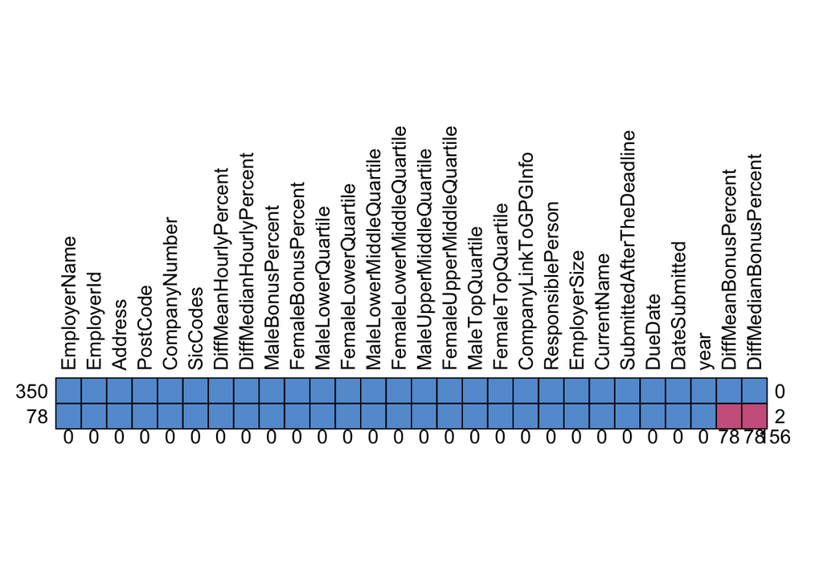

We can see that of the 428 rows of data, 78 had missing values. Those 78 values were both missing the DiffMeanBonusPercent and DiffMedianBonusPercent values.

# 3 Densities

We first look at how a few variables are distributed. First, the average hourly wage difference as a percentage.

Ideally, we would expect the curves to be centered around 0. The Gender Pay Gap is a well documented phenomenom in Economics, so we know beforehand that the curves will not be centered around 0, but what would be ideal is to see the distributions tending toward 0 as time passes.

Select a tab to view the plot.

## 3.1 Density Plots

### 3.1.1 Density of Hourly Wage Differences

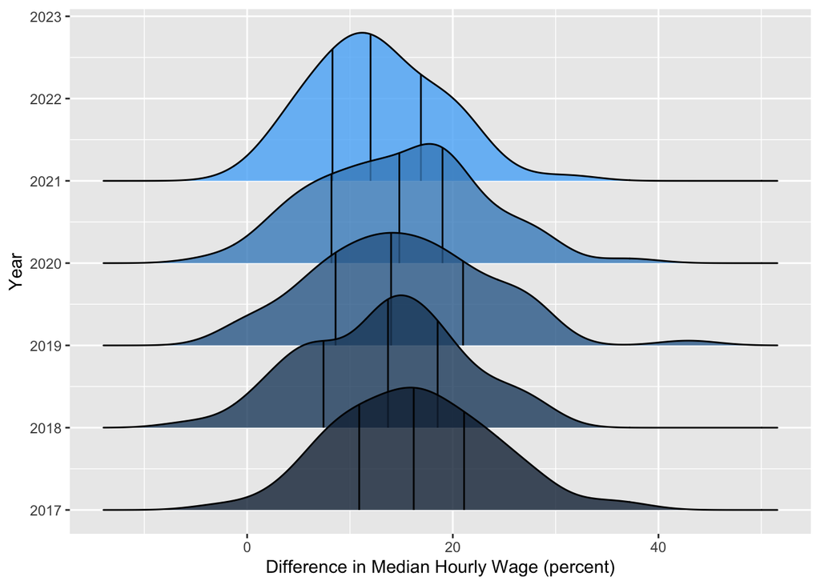

### 3.1.2 Density of Bonus Differences

[figure not shown]

# 4 Relationships

It’s worth looking at how variables in the data set relate to one another.

## 4.1 Difference in Wage & Difference in Bonus

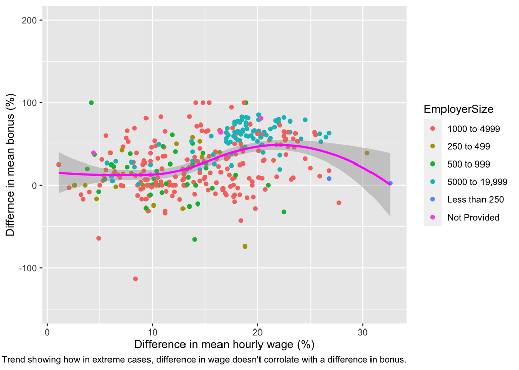

In a plot of wage vs bonus for any given company, one would expect an increasing line of best fit, since higher paid employees would be given higher bonuses due to increased importance within the business. What we see here is that actually up until an hourly wage difference of around 14%, there is minimal difference in bonus difference, which then increases gradually before coming back down at extreme wage differences.

# 5 Regional Variations

In the below interactive map, the dots represent universities in the data set. The darker the colour of the dot, the higher the average difference in hourly wage in the last five years.

[interactive chart not shown]

Interestingly, there seems to be no geographical pattern in the Gender Pay Gap- it is a nationwide phenomenon. Other than a few universities in the Midlands, and a couple in the North, the isn’t much variation.